# Uncovering activation signal in Yost et al.

# Load the reference

```r
# Load the reference
options(timeout = max(900, getOption("timeout")))
#download.file("https://figshare.com/ndownloader/files/38921366", destfile = "CD8T_human_ref_v1.rds")
ref.cd8 <- load.reference.map("CD8T_human_ref_v1.rds")
```

```
## [1] "Loading Custom Reference Atlas..."
## [1] "Loaded Custom Reference map Human CD8 TILs"
```

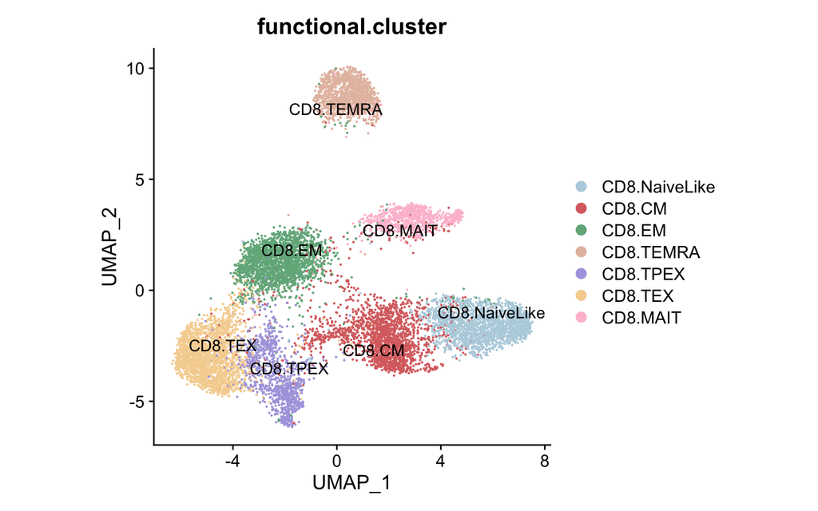

```r
# Setup colors
mycols <- ref.cd8@misc$atlas.palette

# DimPlot
DimPlot(ref.cd8,  group.by = 'functional.cluster', label = T, repel = T, cols = mycols) + theme(aspect.ratio = 1)
```

# Setup data

Data were extracted from [Yost et al. 2019](https://www.nature.com/articles/s41591-019-0522-3) and uploaded on Figshare.

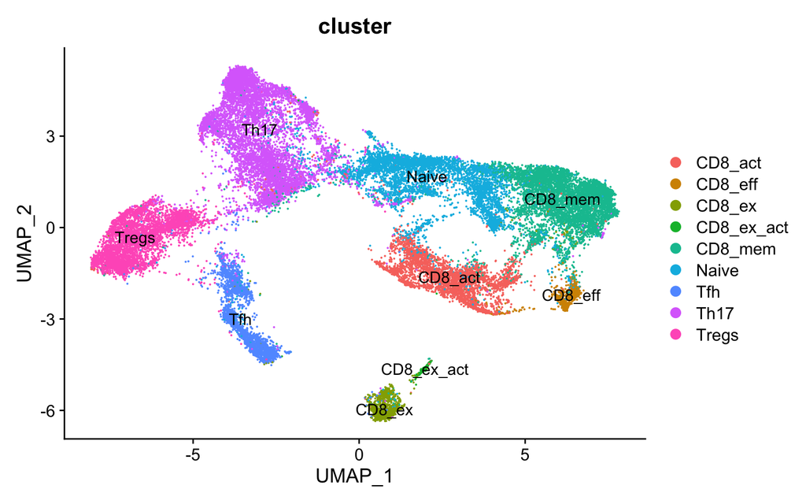

```r
# Load data
#download.file("https://figshare.com/ndownloader/files/39109277", destfile = "Yost.cd3.Rds")
Yost.cd3 <- readRDS("Yost.cd3.Rds")

# Normalize data
Yost.cd3 <- NormalizeData(Yost.cd3)
Yost.cd3 <- ScaleData(Yost.cd3)
# DimPlots
DimPlot(Yost.cd3, reduction = 'umap', group.by = 'cluster', label = T)
```

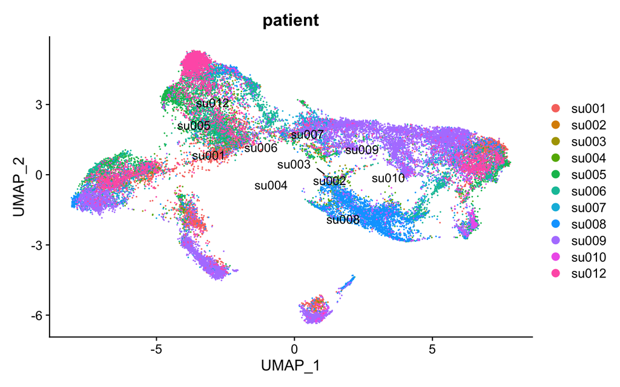

```r
DimPlot(Yost.cd3, reduction = 'umap', group.by = 'patient', label = T, repel = T)
```

Now we can have a look at the original study annotation, including clusters. We can see that the activation cluster (CD8_act) is patient-specific, as it seems driven mainly by patient **su008** after receiving immunotherapy treatment.

# Projection

As this dataset is a mix between CD4 and CD8 T cells, we will keep the parameter `filter.cells` as TRUE to keep only CD8+ T cells.

```r
DefaultAssay(Yost.cd3) <- "RNA"
Yost.cd3 <- ProjecTILs.classifier(Yost.cd3, ref = ref.cd8, filter.cells = T, split.by = 'patient', ncores = 6)
table(Yost.cd3$functional.cluster)
```

```
##
##        CD8.CM        CD8.EM      CD8.MAIT CD8.NaiveLike     CD8.TEMRA
##          3806          5296           316           438           965
##       CD8.TEX      CD8.TPEX
##          2370           499
```

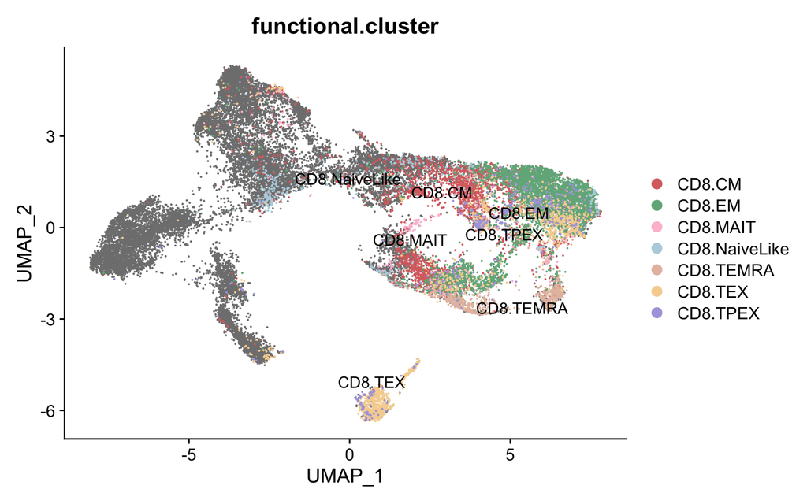

```r
DimPlot(Yost.cd3, group.by = 'functional.cluster', order = T, cols = mycols, label = T, repel = T)
```

We can see that activation signal is contributing to defining UMAP space.

In the **CD8_act** cluster, which is mainly patient specific, we have many cell types projected. Let’s confirm that we can retrieve our reference clusters behind the activation signal.

# Focus on the activated (**CD8_act)** cluster

The cluster **CD8_act** is composed of cells driven by their activation signal. One benefit of projection is to overcome these strong gene programs and focus on the underlying cellular identity.

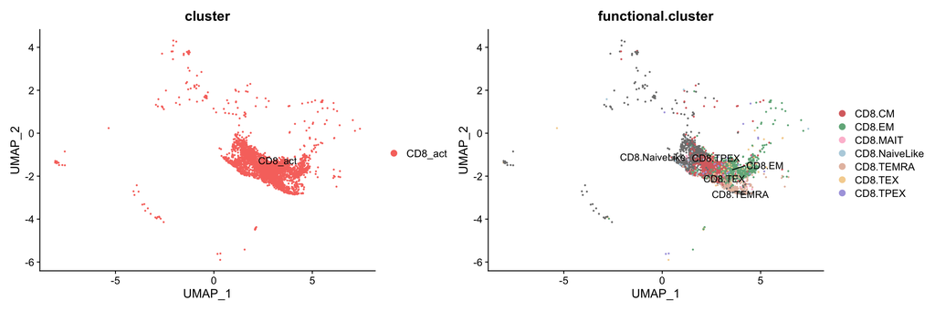

```r
Yost.cd3.sub <- subset(Yost.cd3, subset = cluster == "CD8_act")
DimPlot(Yost.cd3.sub, group.by = "cluster", repel = T, label = T) + DimPlot(Yost.cd3.sub, group.by = "functional.cluster", cols = mycols, repel = T, label = T)
```

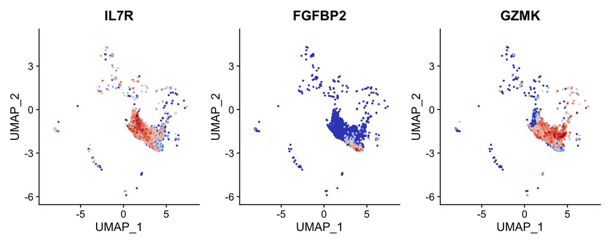

```r
DefaultAssay(Yost.cd3.sub) <- 'RNA'
FeaturePlot(Yost.cd3.sub, features = c('IL7R','FGFBP2','GZMK'), ncol = 3, pt.size = 0.5, order = T, cols = pals::coolwarm()) & NoLegend()
```

We see that in the original reduced space, within the activated cluster, we recover cell types from our CD8 reference, including CM, TEMRA and EM clusters (respectively high for IL7R, FGFBP2 and GZMK). If you are interested in recovering cell types hidden by other transient cell states, you can read more in the [corresponding tutorial](https://carmonalab.github.io/human_CD8_TIL_CaseStudies/Transient_gene_programs.html).